# Appendix G. CDFW ROV Index of Abundance

The California Department of Fish and Wildlife (CDFW) in collaboration with Marine Applied Research and Exploration (MARE) have been conducting remotely operated vehicle (ROV) surveys along the California coast in Marine Protected Areas (MPAs) and reference sites adjacent to them since 2004 for the purposes of long-term monitoring of changes in size, density (fish/square meter) and length of fish and invertebrate species along the California coast. Surveys of the entire coast have now been undertaken twice, each taking three years to complete and each resulting in data combined into super years of 2015 (2014-2016) and 2020 (2019-2021) available for analysis to examine the changes over five years. The 500 m strip survey transects in each rocky reef sample site were selected by first randomly selecting the deepest transect at a given site, then selecting transects on a constant interval into shallower depths. Transects were designed to be oriented parallel to general depth contours, though they were carried out using a fixed bearing that crossed depths in some cases.

```r
data_dir<- "N:/Assessments/CurrentAssessments/copper_rockfish_2023/data"
tab <- read.csv(file.path(data_dir, "survey_indices", "rov", "forSS", "rov_south_model_selection.csv"))

sa4ss::table_format(x = tab,
             caption = "Model selection for the ROV survey.",
             label = "rov-model-selection",
             align = 'l',
             longtable = TRUE,
             font_size = 9,
             landscape = TRUE)
```

[output not shown]

```r
sa4ss::add_figure(
filein = file.path(data_dir, "survey_indices", "rov", "glm_negbin_south_designation_depth_soft", "Index.png"),
caption = "Weighted relative index of abundance estimated south of Point Conception for the CDFW ROV survey.",
label = 'rov-indices')
```

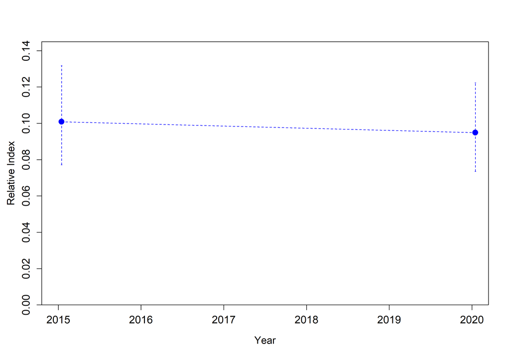

Weighted relative index of abundance estimated south of Point Conception for the CDFW ROV survey.